# Lista 3 - Econometria II

Augusto Floriano, Danyel Lima, Fernando Cruz e Gustavo Darmont

2025-11-12

### (a)

[interactive chart not shown]

Visualmente, nota-se que as séries das taxas longa ($R_t$) e curta ($r_t$) exibem trajetórias parecidas, oscilando em torno de um nível médio e sem tendência determinística clara, com prolongada persistência, indicando possivelmente a existência de raiz unitária. O spread ($S_t = R_t - r_t$) apresenta flutuações de menor amplitude, com valores positivos e negativos, sugerindo estacionariedade. Já a variação da taxa curta ($\Delta r_t$) mostra comportamento mais errático, com oscilações pontuais em torno de zero e sem padrão persistente, similar a um ruído branco.

# Análise visual da ACF

[interactive chart not shown]

A ACF do $R_t$ é positiva e indica um decaimento consideravelmente lento, e longo, num ritmo quase que constante, indicando possivelmente a presença de raiz unitária. Da mesma forma, também se observa uma elevada persistência para $r_t$, cruzando a banda superior do limite do intervalo de confiança somente no lag $16$ e indicando a possibilidade de raiz unitária. No ACF do spread, observa-se uma maior oscilação mas ainda com maior parte dos lags fora do intervalo de confiança. Comportamento totalmente distinto se observa no $Δr_t$, com barras menores, quase todas dentro do intervalo de confiança, e aparentando ruido.

# Testes de raiz unitária

```
## $Rt
##
## ###############################################
## # Augmented Dickey-Fuller Test Unit Root Test #
## ###############################################
##
## Test regression drift
##
##
## Call:
## lm(formula = z.diff ~ z.lag.1 + 1 + z.diff.lag)
##
## Residuals:
##     Min      1Q  Median      3Q     Max
## -3.3195 -0.2761 -0.0479  0.2241  2.6973
##
## Coefficients:
##             Estimate Std. Error t value Pr(>|t|)
## (Intercept)  0.18639    0.15113   1.233    0.220
## z.lag.1     -0.04578    0.02932  -1.561    0.121
## z.diff.lag  -0.16284    0.08552  -1.904    0.059 .
## ---
## Signif. codes:  0 '***' 0.001 '**' 0.01 '*' 0.05 '.' 0.1 ' ' 1
##
## Residual standard error: 0.7671 on 137 degrees of freedom
## Multiple R-squared:  0.05071,    Adjusted R-squared:  0.03685
## F-statistic: 3.659 on 2 and 137 DF,  p-value: 0.02831
##
##
## Value of test-statistic is: -1.5614 1.3043
##
## Critical values for test statistics:
##       1pct  5pct 10pct
## tau2 -3.46 -2.88 -2.57
## phi1  6.52  4.63  3.81
##
##
## $rt
##
## ###############################################
```

[output cut: 91 more lines]

```
## z.diff.lag   0.23351    0.08304   2.812  0.00565 **
## ---
## Signif. codes:  0 '***' 0.001 '**' 0.01 '*' 0.05 '.' 0.1 ' ' 1
##
## Residual standard error: 1.559 on 136 degrees of freedom
## Multiple R-squared:  0.5645, Adjusted R-squared:  0.5581
## F-statistic: 88.14 on 2 and 136 DF,  p-value: < 2.2e-16
##
##
## Value of test-statistic is: -10.8973 59.3773
##
## Critical values for test statistics:
##       1pct  5pct 10pct
## tau2 -3.46 -2.88 -2.57
## phi1  6.52  4.63  3.81
```

Três dos quatro modelos não apresentaram intercepto com significância estatística. Dessa forma, a especificação em formato de passeio aleatório foi adotada por ausência de tendência determinística e de intercepto estatisticamente significativo, conforme indicado tanto pela inspeção visual das séries quanto pelos testes sob “drift”, cujos interceptos foram insignificantes.

```
## $Rt
##
## ###############################################
## # Augmented Dickey-Fuller Test Unit Root Test #
## ###############################################
##
## Test regression none
##
##
## Call:
## lm(formula = z.diff ~ z.lag.1 - 1 + z.diff.lag)
##
## Residuals:
##     Min      1Q  Median      3Q     Max
## -3.5746 -0.2006  0.0384  0.2775  2.5038
##
## Coefficients:
##            Estimate Std. Error t value Pr(>|t|)
## z.lag.1    -0.01312    0.01260  -1.041   0.2997
## z.diff.lag -0.18019    0.08451  -2.132   0.0348 *
## ---
## Signif. codes:  0 '***' 0.001 '**' 0.01 '*' 0.05 '.' 0.1 ' ' 1
##
## Residual standard error: 0.7685 on 138 degrees of freedom
## Multiple R-squared:  0.0411, Adjusted R-squared:  0.0272
## F-statistic: 2.957 on 2 and 138 DF,  p-value: 0.05527
##
##
## Value of test-statistic is: -1.041
##
## Critical values for test statistics:
##       1pct  5pct 10pct
## tau1 -2.58 -1.95 -1.62
##
##
## $rt
##
## ###############################################
## # Augmented Dickey-Fuller Test Unit Root Test #
## ###############################################
```

[output cut: 83 more lines]

```
## z.lag.1    -1.32612    0.12152 -10.912  < 2e-16 ***
## z.diff.lag  0.23220    0.08279   2.805  0.00577 **
## ---
## Signif. codes:  0 '***' 0.001 '**' 0.01 '*' 0.05 '.' 0.1 ' ' 1
##
## Residual standard error: 1.555 on 137 degrees of freedom
## Multiple R-squared:  0.5636, Adjusted R-squared:  0.5572
## F-statistic: 88.46 on 2 and 137 DF,  p-value: < 2.2e-16
##
##
## Value of test-statistic is: -10.9124
##
## Critical values for test statistics:
##       1pct  5pct 10pct
## tau1 -2.58 -1.95 -1.62
```

Com o modelo sem intercepto, não se rejeita a hipótese nula de existência de raiz unitária tanto para a taxa longa ($R_t$) quanto para a curta ($r_t$). Contudo, tanto o spread ($S_t$) quanto a diferença na taxa curta ($\Delta_t$) apresentam parâmetro significativo no primeiro lag em nível (parâmetro de regressão à média, por simplificação). Logo, assumiremos $R_t$ e $r_t$ não-estacionárias e $S_t$ e $\Delta_t$ estacionárias.

### (b)

Para escolher o número de defasagens:

```
##
## Constante
```

```
## AIC(n)  HQ(n)  SC(n) FPE(n)
##      2      2      2      2
```

```
##
## Tendência
```

```
## AIC(n)  HQ(n)  SC(n) FPE(n)
##      2      2      1      2
```

```
##
## Ambos
```

```
## AIC(n)  HQ(n)  SC(n) FPE(n)
##      2      2      1      2
```

As escolhas razoáveis são, nessa lógica, p = 1 (com constante e elemento de tendência) ou p = 2 (com termo constante sem tendência).

Estimando os modelos VAR(p) em ambas as hipóteses:

```
## Resultados para: VAR(1)
##
## VAR Estimation Results:
## =========================
## Endogenous variables: Rt, rt
## Deterministic variables: both
## Sample size: 141
## Log Likelihood: -373.354
## Roots of the characteristic polynomial:
## 0.9158 0.4522
## Call:
## VAR(y = d_teste, p = p_both, type = "both", exogen = NULL)
##
##
## Estimation results for equation Rt:
## ===================================
## Rt = Rt.l1 + rt.l1 + const + trend
##
##       Estimate Std. Error t value Pr(>|t|)
## Rt.l1 0.702807   0.066851  10.513  < 2e-16 ***
## rt.l1 0.192363   0.048625   3.956 0.000122 ***
## const 0.053779   0.159556   0.337 0.736593
## trend 0.005537   0.002058   2.690 0.008024 **
## ---
## Signif. codes:  0 '***' 0.001 '**' 0.01 '*' 0.05 '.' 0.1 ' ' 1
##
##
## Residual standard error: 0.7357 on 137 degrees of freedom
## Multiple R-Squared: 0.896,   Adjusted R-squared: 0.8937
## F-statistic: 393.5 on 3 and 137 DF,  p-value: < 2.2e-16
##
##
## Estimation results for equation rt:
## ===================================
## rt = Rt.l1 + rt.l1 + const + trend
##
##        Estimate Std. Error t value Pr(>|t|)
## Rt.l1  0.277566   0.138587   2.003   0.0472 *
## rt.l1  0.665227   0.100804   6.599 8.33e-10 ***
## const  0.660902   0.330771   1.998   0.0477 *
```

[output cut: 69 more lines]

```
## Residual standard error: 1.527 on 135 degrees of freedom
## Multiple R-Squared: 0.7132,  Adjusted R-squared: 0.7047
## F-statistic: 83.92 on 4 and 135 DF,  p-value: < 2.2e-16
##
##
##
## Covariance matrix of residuals:
##        Rt     rt
## Rt 0.4964 0.6593
## rt 0.6593 2.3319
##
## Correlation matrix of residuals:
##        Rt     rt
## Rt 1.0000 0.6128
## rt 0.6128 1.0000
```

Dado que ambos os modelos possuem resultados estatisticamente significantes, o critério para escolha do modelo mais apropriado será pelos testes diagnósticos:

```
## VAR(1) com constante e termo de tendência de LP
```

```
##
##  Autocorrelação Serial
##
##  Portmanteau Test (asymptotic)
##
## data:  Residuals of VAR object modelo
## Chi-squared = 75.956, df = 60, p-value = 0.08015
##
##
##  Normalidade dos resíduos (Jarque-Bera)
## $JB
##
##  JB-Test (multivariate)
##
## data:  Residuals of VAR object modelo
## Chi-squared = 109.82, df = 4, p-value < 2.2e-16
##
##
## $Skewness
##
##  Skewness only (multivariate)
##
## data:  Residuals of VAR object modelo
## Chi-squared = 8.3182, df = 2, p-value = 0.01562
##
##
## $Kurtosis
##
##  Kurtosis only (multivariate)
##
## data:  Residuals of VAR object modelo
## Chi-squared = 101.5, df = 2, p-value < 2.2e-16
##
##
##
##  Heteroscedasticidade dos resíduos
##
##  ARCH (multivariate)
##
## data:  Residuals of VAR object modelo
## Chi-squared = 176.21, df = 45, p-value < 2.2e-16
```

```
## $arch.mul
##
##  ARCH (multivariate)
##
## data:  Residuals of VAR object modelo
## Chi-squared = 176.21, df = 45, p-value < 2.2e-16
```

```
## VAR(2) com constante
```

```
##
##  Autocorrelação Serial
##
##  Portmanteau Test (asymptotic)
##
## data:  Residuals of VAR object modelo
## Chi-squared = 61.529, df = 56, p-value = 0.2848
##
##
##  Normalidade dos resíduos (Jarque-Bera)
## $JB
##
##  JB-Test (multivariate)
##
## data:  Residuals of VAR object modelo
## Chi-squared = 61.704, df = 4, p-value = 1.272e-12
##
##
## $Skewness
##
##  Skewness only (multivariate)
##
## data:  Residuals of VAR object modelo
## Chi-squared = 2.9989, df = 2, p-value = 0.2233
##
##
## $Kurtosis
##
##  Kurtosis only (multivariate)
##
## data:  Residuals of VAR object modelo
## Chi-squared = 58.705, df = 2, p-value = 1.789e-13
##
##
##
##  Heteroscedasticidade dos resíduos
##
##  ARCH (multivariate)
##
## data:  Residuals of VAR object modelo
## Chi-squared = 144.94, df = 45, p-value = 1.964e-12
```

```
## $arch.mul
##
##  ARCH (multivariate)
##
## data:  Residuals of VAR object modelo
## Chi-squared = 144.94, df = 45, p-value = 1.964e-12
```

Comparando os testes de Portmanteau (Ljung-Box) dos modelos, vemos que o VAR(1) tem hipótese nula de ausência de autocorrelação serial rejeitada a 8%, enquanto o VAR(2) tem p valor na casa dos 28%, ou seja, há mais confiança na especificação do segundo caso. Quanto a normalidade dos resíduos e heteroscedasticidade condicional, ambos os modelos possuem resíduos distribuídos de forma não-normal e clusters de volatilidade, fazendo do primeiro critério de comparação o definitivo para escolher o VAR(2).

Tendo escolhido o VAR(2), realiza-se o teste de cointegração de Johansen para determinar o vetor de cointegração das séries:

```
##
##  Teste por traço:
```

```
##
## ######################
## # Johansen-Procedure #
## ######################
##
## Test type: trace statistic , with linear trend
##
## Eigenvalues (lambda):
## [1] 0.18726281 0.01764964
##
## Values of teststatistic and critical values of test:
##
##           test 10pct  5pct  1pct
## r <= 1 |  2.49  6.50  8.18 11.65
## r = 0  | 31.52 15.66 17.95 23.52
##
## Eigenvectors, normalised to first column:
## (These are the cointegration relations)
##
##           Rt.l2      rt.l2
## Rt.l2  1.000000  1.0000000
## rt.l2 -1.070742 -0.1976301
##
## Weights W:
## (This is the loading matrix)
##
##            Rt.l2       rt.l2
## Rt.d -0.05760025 -0.05050198
## rt.d  0.30057903 -0.08970732
```

```
##
##  Teste por autovalores
```

```
##
## ######################
## # Johansen-Procedure #
## ######################
##
## Test type: maximal eigenvalue statistic (lambda max) , with linear trend
##
## Eigenvalues (lambda):
## [1] 0.18726281 0.01764964
##
## Values of teststatistic and critical values of test:
##
##           test 10pct  5pct  1pct
## r <= 1 |  2.49  6.50  8.18 11.65
## r = 0  | 29.03 12.91 14.90 19.19
##
## Eigenvectors, normalised to first column:
## (These are the cointegration relations)
##
##           Rt.l2      rt.l2
## Rt.l2  1.000000  1.0000000
## rt.l2 -1.070742 -0.1976301
##
## Weights W:
## (This is the loading matrix)
##
##            Rt.l2       rt.l2
## Rt.d -0.05760025 -0.05050198
## rt.d  0.30057903 -0.08970732
```

```
##
## Vetor de Cointegração (Beta) normalizado para Rt:
```

```
##     Rt.l2     rt.l2
##  1.000000 -1.070742
```

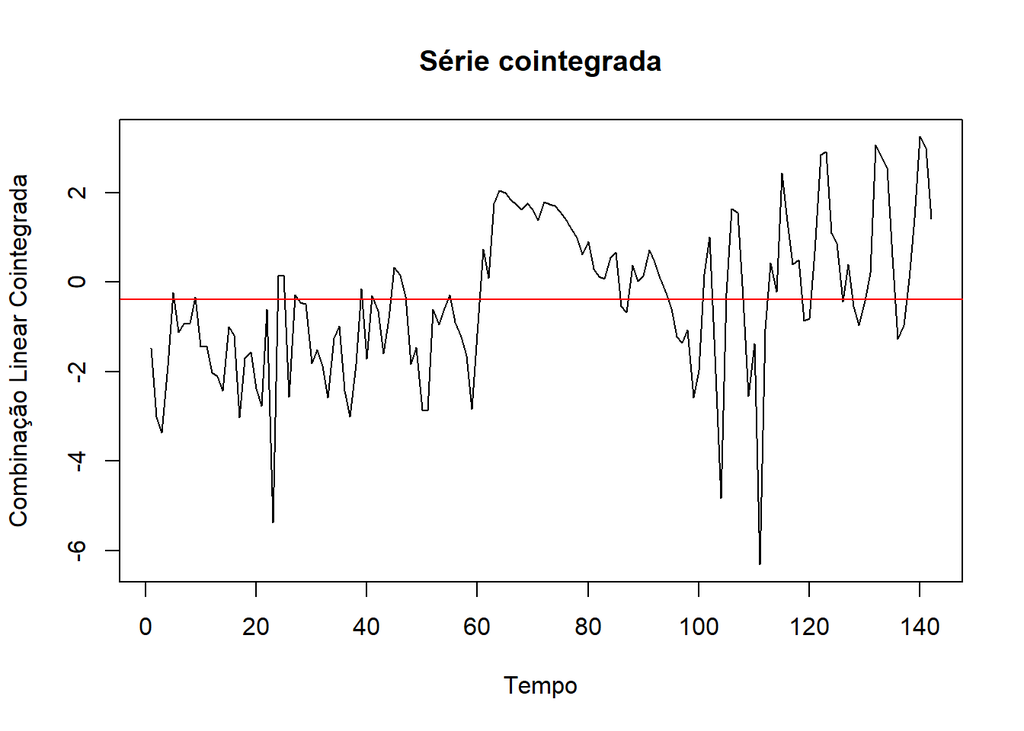

O vetor de cointegração ecnontrado foi (1, -1.0707). Rodando o comando para cálculo do VECM, podemos corroborar o achado e, por fim, montar as equações do modelo:

```
##
##  Coeficientes do VECM
```

```
## $rlm
##
## Call:
## lm(formula = substitute(form1), data = data.mat)
##
## Coefficients:
##           Rt.d      rt.d
## ect1      -0.05760   0.30058
## constant  -0.04413   0.06695
## Rt.dl1    -0.48885   0.01735
## rt.dl1     0.25599  -0.16530
##
##
## $beta
##            ect1
## Rt.l2  1.000000
## rt.l2 -1.070742
```

```
##
##  Coeficientes da representação VAR(2)
```

```
##
## Coefficient matrix of lagged endogenous variables:
##
## A1:
##        Rt.l1     rt.l1
## Rt 0.5111492 0.2559867
## rt 0.0173451 0.8346951
##
##
## A2:
##        Rt.l2      rt.l2
## Rt 0.4312506 -0.1943117
## rt 0.2832339 -0.1565376
##
##
## Coefficient matrix of deterministic regressor(s).
##
##       constant
## Rt -0.04412599
## rt  0.06694682
```

Com isso, o modelo VECM assume a seguinte forma (note que o vetor beta calculado confere com o exposto nesses comandos):
$$\begin{pmatrix} \Delta R_t \\ \Delta r_t
\end{pmatrix} = \underbrace{ \begin{pmatrix} -0.0576 \\ 0.3006
\end{pmatrix} }_{\alpha} \underbrace{ \begin{pmatrix} 1.00 & -1.0707
\end{pmatrix} }_{\beta'} \begin{pmatrix} R_{t-1} \\ r_{t-1}
\end{pmatrix} + \underbrace{ \begin{pmatrix} -0.4889 & 0.2560 \\
0.0173 & -0.1653 \end{pmatrix} }_{\Gamma_1} \begin{pmatrix} \Delta
R_{t-1} \\ \Delta r_{t-1} \end{pmatrix} + \underbrace{ \begin{pmatrix}
-0.0441 \\ 0.0669 \end{pmatrix} }_{C_0} + \begin{pmatrix} \epsilon_{R,t}
\\ \epsilon_{r,t} \end{pmatrix}$$
Esse VECM possui, fazendo o caminho contrário do Teorema da Identificação de Granger, uma forma VAR(2), tal qual:
$$\begin{pmatrix} R_t \\ r_t \end{pmatrix}
=
\underbrace{
\begin{pmatrix} 0.5111 & 0.2560 \\ 0.0173 & 0.8347 \end{pmatrix}
}_{A_1}
\begin{pmatrix} R_{t-1} \\ r_{t-1} \end{pmatrix}
+
\underbrace{
\begin{pmatrix} 0.4313 & -0.1943 \\ 0.2832 & -0.1565
\end{pmatrix}
}_{A_2}
\begin{pmatrix} R_{t-2} \\ r_{t-2} \end{pmatrix}
+
\underbrace{
\begin{pmatrix} -0.0441 \\ 0.0669 \end{pmatrix}
}_{C_0}
+
\begin{pmatrix} \epsilon_{R,t} \\ \epsilon_{r,t} \end{pmatrix}$$

### (c)

Montando o VAR com a mesma metodologia do item anterior, mas agora para $ S_t $ e $r_t $:

```
##
##  Retorno dos critérios
```

```
## AIC(n)  HQ(n)  SC(n) FPE(n)
##      4      2      2      4
```

```
##
## VAR Estimation Results:
## =========================
## Endogenous variables: St, drt
## Deterministic variables: const
## Sample size: 139
## Log Likelihood: -367.515
## Roots of the characteristic polynomial:
## 0.7455 0.4034 0.3987 0.3987
## Call:
## VAR(y = na.omit(dados_pvm), p = p_pvm, type = "const", exogen = NULL)
##
##
## Estimation results for equation St:
## ===================================
## St = St.l1 + drt.l1 + St.l2 + drt.l2 + const
##
##        Estimate Std. Error t value Pr(>|t|)
## St.l1   0.43772    0.17700   2.473   0.0146 *
## drt.l1 -0.13070    0.14112  -0.926   0.3560
## St.l2   0.22600    0.17027   1.327   0.1867
## drt.l2  0.10801    0.07660   1.410   0.1608
## const   0.02449    0.10429   0.235   0.8147
## ---
## Signif. codes:  0 '***' 0.001 '**' 0.01 '*' 0.05 '.' 0.1 ' ' 1
##
##
## Residual standard error: 1.226 on 134 degrees of freedom
## Multiple R-Squared: 0.3892,  Adjusted R-squared: 0.371
## F-statistic: 21.35 on 4 and 134 DF,  p-value: 1.223e-13
##
##
## Estimation results for equation drt:
## ====================================
## drt = St.l1 + drt.l1 + St.l2 + drt.l2 + const
##
##        Estimate Std. Error t value Pr(>|t|)
## St.l1   0.06613    0.22173   0.298    0.766
## drt.l1 -0.10504    0.17678  -0.594    0.553
## St.l2   0.19488    0.21330   0.914    0.363
## drt.l2 -0.11835    0.09595  -1.233    0.220
## const  -0.04971    0.13064  -0.381    0.704
##
##
## Residual standard error: 1.535 on 134 degrees of freedom
## Multiple R-Squared: 0.1021,  Adjusted R-squared: 0.07528
## F-statistic: 3.809 on 4 and 134 DF,  p-value: 0.005768
##
##
##
## Covariance matrix of residuals:
##         St    drt
## St   1.502 -1.676
## drt -1.676  2.357
##
## Correlation matrix of residuals:
##          St     drt
## St   1.0000 -0.8909
## drt -0.8909  1.0000
```

Para verificar se o modelo atende às condições de um Modelo de Valor Presente (PVM), há de se verificar se ele atende à seguinte especificação, sendo $\delta$ a taxa de desconto intertemporal:

$$S_t + \Delta r_t = \frac{1}{\delta}
S_{t-1} + \mu_t$$
No caso de um VAR(2), soma-se as duas equações a seguir para se chegar na original por manipulação algébrica:
$$\begin{align*}
S_t &= a_1 S_{t-1} + a_2 S_{t-2} + b_1 \Delta r_{t-1} + b_2 \Delta
r_{t-2} + u_{1t} \\
\Delta r_t &= c_1 S_{t-1} + c_2 S_{t-2} + d_1 \Delta r_{t-1} + d_2
\Delta r_{t-2} + u_{2t}
\end{align*}$$
Ou seja, devemos testar as seguintes restrições no teste de Wald:
$$H_0 : \begin{cases} a_1 + c_1 =
\frac{1}{\delta} \\ a_2 + c_2 = 0 \\ b_1 + d_1 = 0 \\ b_2 + d_2 = 0
\end{cases}$$

```
##
## Teste de Wald para as condições do PVM (H0: Restrições são válidas):
```

```
## Linear hypothesis test (Theil's F test)
##
## Hypothesis:
## eq1_St.l1  + eq2_St.l1 = 1.0989010989011
## eq1_St.l2  + eq2_St.l2 = 0
## eq1_drt.l1  + eq2_drt.l1 = 0
## eq1_drt.l2  + eq2_drt.l2 = 0
##
## Model 1: restricted model
## Model 2: var_sur
##
##   Res.Df Df      F Pr(>F)
## 1    272
## 2    268  4 0.9342 0.4445
```

### (d)

```
##
## --- Funções de Impulso-Resposta (IRF) Interativas ---
```

[interactive chart not shown]

O primeiro gráfico mede a resposta das variáveis a um choque na taxa curta ($r_t$), note que tanto a taxa curta ($r_t$) quanto a longa ($R_t$) sofrem impacto significativo e maior que 0.5 mesmo nos maiores lags.

Já o segundo gráfico mede a resposta das variáveis a um choque na taxa longa ($R_t$), note que enquanto o resultado de $R_t$ é significativamente afetado em todos os lags, o impacto na taxa curta ($r_t$) não é estatisticamente diferente de 0 nos primeiros lags, e só nos lags mais longos o impacto passa a ser estatisticamente significativo e diferente de 0.

Esses resultados estão em linha com a abordagem adotada de utilizar $r_t$ como a variável mais exógena.

```
##
## --- Decomposição da Variância do Erro de Previsão (FEVD) ---
```

```
## $rt
##              rt          Rt
##  [1,] 1.0000000 0.000000000
##  [2,] 0.9999733 0.000026732
##  [3,] 0.9940580 0.005941971
##  [4,] 0.9854444 0.014555591
##  [5,] 0.9738656 0.026134391
##  [6,] 0.9612530 0.038746955
##  [7,] 0.9482288 0.051771233
##  [8,] 0.9354106 0.064589361
##  [9,] 0.9230732 0.076926843
## [10,] 0.9113765 0.088623513
## [11,] 0.9003762 0.099623819
## [12,] 0.8900780 0.109921989
## [13,] 0.8804569 0.119543090
```

[output cut: 30 more lines]

Os resultados da Decomposição de Cholesky parecem corroborar a ideia de usar o $r_t$ como variável mais exógena. Analisando primeiramente $r_t$, percebemos que, como esperado, o erro é explicado 100% por $r_t$ no primeiro lag, o que é coerente com a nossa abordagem, considerando $r_t$ como variável mais exógena. Note, porém, que no lag 20 aproximadamente 83% do erro em $r_t$ é explicado pelo próprio $r_t$, o que dá indícios de que o $r_t$ é de fato pouco impactado por $R_t$, corroborando a ideia de ser a variável mais exógena.

Já analisando os erros de $R_t$, percebemos que, apesar de no início o erro ser explicado em maior parte pelo próprio $R_t$, do lag 6 para frente a decomposição do erro mais ou menos se estabiliza, com $r_t$ explicando cerca de 63% do erro. Essa conclusão indica que o $R_t$ parece ter características de uma variável endógena, novamente confirmando a coerência da abordagem sugerida.

Essa conclusão faz sentido, uma vez que a taxa de juros de curto prazo ($r_t$) costuma ser determinada pelo “policy maker” (Banco Central). Apesar de este costumar ter alguma espécie de modelagem para auxiliar na política monetária, a definição final acaba sendo, de certa forma, discricionária. Dessa forma, acaba sendo de fato uma variável mais exógena, por ter uma correlação clara com a taxa de longo prazo ($R_t$). Esta, por outro lado, é resultado da expectativa do mercado para a economia, que é diretamente influenciada pela política monetária empregada pelo “policy maker” no curto prazo.

### (e)

Uma vez que nos itens anteriores se confirmou a presença de vetor de cointegração para a série, seguiremos os mesmos passos de construção do VECM para a resolução a seguir, verificando a cada passo se o modelo é adequado para a subamostra dos dados.

1. Preparar Dados em Nível (1871-2000)

```
## # A tibble: 6 × 3
##    Year    rt    Rt
##   <dbl> <dbl> <dbl>
## 1  1871  6.35  5.32
## 2  1872  7.81  5.36
## 3  1873  8.35  5.58
## 4  1874  6.86  5.47
## 5  1875  4.96  5.07
## 6  1876  5.33  4.59
```

```
## # A tibble: 6 × 2
##      rt    Rt
##   <dbl> <dbl>
## 1  6.35  5.32
## 2  7.81  5.36
## 3  8.35  5.58
## 4  6.86  5.47
## 5  4.96  5.07
## 6  5.33  4.59
```

[interactive chart not shown]

Com base nos gráficos acima, observa-se que não há uma tendência linear determinística clara, mas tampouco as taxas variam em torno de zero. Dessa forma, entende-se que o modelo pode ser especificado como type = “const”, o que, assim como na letra (b), se motiva pela justificativa teórica fornecida pelo Modelo de Valor Presente (Handout 01.4, Eq. 7), que postula que o spread ($S_t = R_t - r_t$) — que é a própria relação de cointegração — é estacionário em torno de uma média constante, $c_n$, e esta constante $c_n$ tem a interpretação econômica direta de um prêmio de risco (risk premium).

2. Selecionar Ordem do VAR (p) para o VECM

```
## --- Seleção de Lags (VAR em Nível) para Amostra até 2000 ---
```

```
## AIC(n)  HQ(n)  SC(n) FPE(n)
##      5      2      2      5
```

Por hora, opta-se pelo modelo $p = 2$ por ser mais parcimonioso.

```
##
## Usando K= 2 (que corresponde a p= 2  no VAR em nível) para o VECM.
```

3. Estimar o VECM (Teste de Johansen)

```
##
## --- Teste de Johansen (Amostra até 2000) ---
```

```
##
## ######################
## # Johansen-Procedure #
## ######################
##
## Test type: trace statistic , without linear trend and constant in cointegration
##
## Eigenvalues (lambda):
## [1]  1.817823e-01  1.686878e-02 -8.154589e-18
##
## Values of teststatistic and critical values of test:
##
##           test 10pct  5pct  1pct
## r <= 1 |  2.18  7.52  9.24 12.97
## r = 0  | 27.86 17.85 19.96 24.60
##
## Eigenvectors, normalised to first column:
## (These are the cointegration relations)
##
##               rt.l2    Rt.l2   constant
## rt.l2     1.0000000  1.00000   1.000000
## Rt.l2    -0.9176926 -4.48505  -1.595412
## constant -0.5128021 16.72326 -17.890982
##
## Weights W:
## (This is the loading matrix)
##
##            rt.l2      Rt.l2     constant
## rt.d -0.33922453 0.01884171 1.227021e-17
## Rt.d  0.05265938 0.01086241 6.883179e-19
```

O teste de Johansen para a subamostra até 2000, assim como na amostra completa, indica a existência de r = 1 vetor de cointegração. Isso confirma que a metodologia VECM é a correta.

4. Converter VECM para VAR e rodar Cholesky

```
##
## --- Análise de Impulso-Resposta e FEVD (Amostra até 2000) ---
```

```
##
## --- Teste de Autocorrelação Serial para o VECM (p=2) ---
```

```
##
##  Portmanteau Test (asymptotic)
##
## data:  Residuals of VAR object var_from_vecm_2000
## Chi-squared = 39.681, df = 34, p-value = 0.2315
```

```
## $serial
##
##  Portmanteau Test (asymptotic)
##
## data:  Residuals of VAR object var_from_vecm_2000
## Chi-squared = 39.681, df = 34, p-value = 0.2315
```

```
## $rt
##              rt           Rt
##  [1,] 1.0000000 0.000000e+00
##  [2,] 0.9999693 3.069304e-05
##  [3,] 0.9934070 6.593000e-03
##  [4,] 0.9844499 1.555014e-02
##  [5,] 0.9725130 2.748695e-02
##  [6,] 0.9594452 4.055475e-02
##  [7,] 0.9459083 5.409168e-02
##  [8,] 0.9325086 6.749138e-02
##  [9,] 0.9195554 8.044457e-02
## [10,] 0.9072260 9.277402e-02
## [11,] 0.8955952 1.044048e-01
## [12,] 0.8846808 1.153192e-01
## [13,] 0.8744662 1.255338e-01
```

[output cut: 30 more lines]

Observando os resultados do Portmanteau Test (asymptotic), conclúi-se que os resíduos do modelo são “ruído branco” (não há autocorrelação serial), uma vez que p-value = 0.2315 > 0.05. Isso significa que a escolha de $p = 2$ (ou $K = 2$ no ca.jo) é suficiente para capturar a dinâmica de autocorrelação do sistema. O VECM para a subamostra até 2000 está bem especificado, gerando, portanto, resultados confiáveis.

Analisando agora os resultados econômicos do modelo, nota-se que a taxa curta (rt) é altamente exógena nesta subamostra. Ela se move primariamente por conta própria e não é muito afetada por choques na taxa longa, uma vez que no horizonte de 1 defasagem temos que 100% de seu comportamento é explicado por ela mesma e no horizonte de 20 defasagens, 82% de seu comportamento ainda é explicado por ela mesma. Isso é consistente com a teoria do item (d) de que rt é a variável de política monetária (definida pelo Banco Central). Por outro lado, a taxa longa (Rt) é altamente endógena. A maior parte de sua variância (62%) no longo prazo é explicada por choques na taxa curta enquanto que no curto prazo 40% de seu comportamento já é explicado por rt.

Assim, entende-se que os resultados seguem em linha com os observados para a amostra completa.

5. Plotar as Funções de Impulso-Resposta

```
##
## --- Funções de Impulso-Resposta (Amostra até 2000) ---
```

[interactive chart not shown]

Com base nos gráficos de Impulso-Resposta (IRF) para a subamostra (até 2000), os resultados corroboram fortemente a abordagem de Cholesky que utiliza $r_t$ como a variável mais exógena.

Analisando primeiramente a linha inferior (Impulso em ‘$Rt$’), o gráfico da “Resposta de rt a Rt” mostra que um choque inesperado na taxa longa ($R_t$) gera respostas de baixa magnitude na taxa curta ($r_t$), sendo estatísticamente zero até o Horizonte 4, uma vez que o intervalo de confiança (a área vermelha) contém a linha do zero nos primeiros horizontes de tempo.

Já analisando a linha superior (Impulso em ‘$rt$’), vemos o oposto. Um choque na taxa curta ($r_t$) gera uma resposta positiva, estatisticamente significativa e persistente na taxa longa (‘Resposta de Rt a rt’).

Essa conclusão, de que $r_t$ afeta $R_t$, mas $R_t$ não afeta de forma significativa $r_t$, valida a ordenação de Cholesky. A interpretação econômica é a mesma do item (d) mencionada anteriormente: a taxa de juros de curto prazo ($r_t$) atua como a variável de política monetária (definida pelo Banco Central) e, portanto, é mais exógena. Um choque nessa política tem um impacto claro e duradouro sobre as expectativas do mercado, que formam a taxa longa ($R_t$). Por outro lado, um choque nas expectativas de mercado ($R_t$) não parece, nesta amostra, forçar uma reação da autoridade monetária, confirmando o caráter mais exógeno de $r_t$.

Uma vez definido o modelo mais adequado e os parâmetros de melhor ajuste, é aplicada a função predict() para projetar os dados de 2001 a 2012 a partir do modelo treinado.

```
## $rt
##           fcst     lower     upper       CI
##  [1,] 6.191141 3.2518933  9.130389 2.939248
##  [2,] 6.281456 2.5614891 10.001423 3.719967
##  [3,] 6.236718 2.1301126 10.343323 4.106605
##  [4,] 6.237119 1.8665639 10.607674 4.370555
##  [5,] 6.228982 1.6603147 10.797650 4.568668
##  [6,] 6.226087 1.4924923 10.959682 4.733595
##  [7,] 6.223524 1.3444410 11.102607 4.879083
##  [8,] 6.222053 1.2095099 11.234596 5.012543
##  [9,] 6.221041 1.0831000 11.358983 5.137941
## [10,] 6.220400 0.9628125 11.477987 5.257587
## [11,] 6.219978 0.8471032 11.592854 5.372875
## [12,] 6.219706 0.7350178 11.704394 5.484688
##
## $Rt
##           fcst    lower     upper       CI
##  [1,] 6.100767 4.747204  7.454330 1.353563
##  [2,] 6.257212 4.370039  8.144384 1.887172
##  [3,] 6.210694 3.957603  8.463785 2.253091
##  [4,] 6.222683 3.658425  8.786941 2.564258
##  [5,] 6.218447 3.383151  9.053743 2.835296
##  [6,] 6.219120 3.139002  9.299238 3.080118
##  [7,] 6.218582 2.913466  9.523698 3.305116
##  [8,] 6.218510 2.703749  9.733271 3.514761
##  [9,] 6.218384 2.506417  9.930352 3.711968
## [10,] 6.218325 2.319487 10.117163 3.898838
## [11,] 6.218280 2.141362 10.295198 4.076918
## [12,] 6.218253 1.970858 10.465647 4.247394
```

Selecionando as séries real e projetada para o período de 2001 a 2012, plotam-se os gráficos e as estatísticas descritivas das séries para que se possa analisar os resultados.

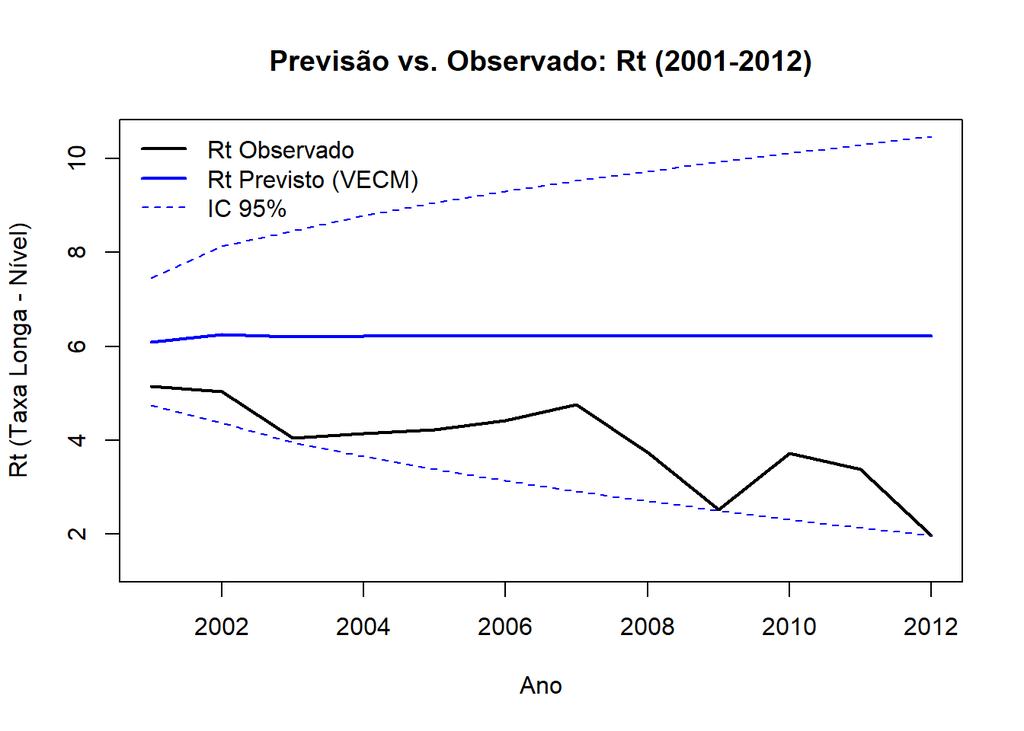

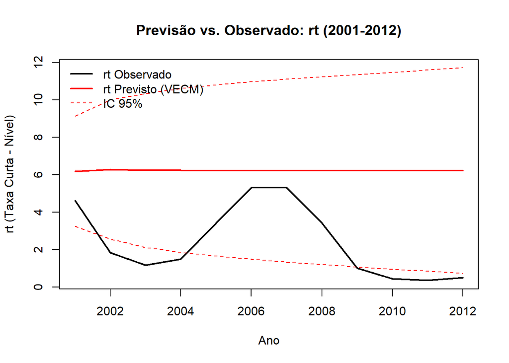

```
## [1] "Estatísticas das Séries (Níveis)"
```

```
##                 Media Desvio_Pad   Minimo   Maximo
## Rt_Observado 3.929167 0.95433421 1.970000 5.160000
## Rt_Previsto  6.211605 0.03676466 6.100767 6.257212
## rt_Observado 2.416250 1.91159396 0.365000 5.340000
## rt_Previsto  6.227351 0.02060356 6.191141 6.281456
```

A partir da análise gráfica e das estatísticas descritivas, percebe-se uma drástica diferença de comportamento entre os dados projetados pelo VECM e os dados reais de 2001 a 2012, com os dados projetados exibindo uma estabilidade muito maior.

Isso é confirmado pela comparação do desvio padrão e dos valores extremos (Mínimo, Máximo): as séries observadas são visivelmente mais voláteis do que as séries previstas. A rt observada (Desvio Padrão = 1.91) é quase 100 vezes mais volátil que a sua previsão (Desvio Padrão = 0.02). Essa discrepância é esperada, uma vez que o modelo VECM foi treinado com dados de 1871 a 2000 e sua previsão converge para a média de longo prazo estimada nesse período. Ele não poderia antecipar os choques estruturais da crise financeira de 2008 e a subsequente política de “Zero Lower Bound”, por exemplo.

Outra análise importante é a comparação das médias, a qual revela uma falha severa do modelo fora da amostra: A média prevista para Rt (6.21) e rt (6.22) é drasticamente diferente da média realmente observada no período (Rt = 3.92 e rt = 2.41). Isso indica que a “normalidade” (a média de longo prazo) do período pós-2000 é estruturalmente diferente daquela do período 1871-2000.

Além disso, a análise dos intervalos de confiança (IC) melhor expõe a quebra estrutural. Ao contrário do que se poderia esperar, as observações reais não permanecem dentro do IC de 95%. O gráfico da Taxa Curta (rt) mostra que a série observada (preta) mergulha para perto de zero, posicionando-se abaixo do limite inferior do IC (linha pontilhada vermelha). O mesmo não ocorre com a Taxa Longa (Rt), contudo, ela tangencia o limite inferior do intervalo de confiança. Isso demonstra que os choques reais pós-2008 não foram apenas “grandes”, mas sim eventos estatisticamente “impossíveis” (com menos de 5% de chance) sob a ótica da distribuição de previsão do modelo treinado até 2000.